# Pair-Wise Distance Between Profiles and Mixed Variable Types

D.E. Beaudette

2023-06-08

# Setup R Envionment

If you have never used the [aqp](http://ncss-tech.github.io/AQP/aqp/aqp-intro.html) or [soilDB](http://ncss-tech.github.io/AQP/soilDB/soilDB-Intro.html) packages before, you will likely need to install them. This only needs to be done once.

```r
# stable versions + deps
install.packages('aqp', dep=TRUE)
install.packages('soilDB', dep=TRUE)
install.packages('sharpshootR', dep=TRUE)

# latest versions
devtools::install_github("ncss-tech/aqp", dependencies=FALSE, upgrade_dependencies=FALSE)
devtools::install_github("ncss-tech/sharpshootR", dependencies=FALSE, upgrade_dependencies=FALSE)
```

Once you have all of the R packages on which this document depends, it is a good idea to load them. R packages must be **installed** anytime you change versions of R (e.g., after an upgrade) and **loaded** anytime you want to access functions from within those packages.

```r
library(aqp)
library(soilDB)
library(sharpshootR)
library(cluster)
library(RColorBrewer)
library(ape)
library(dendextend)
```

# Simple Example via Soil Texture

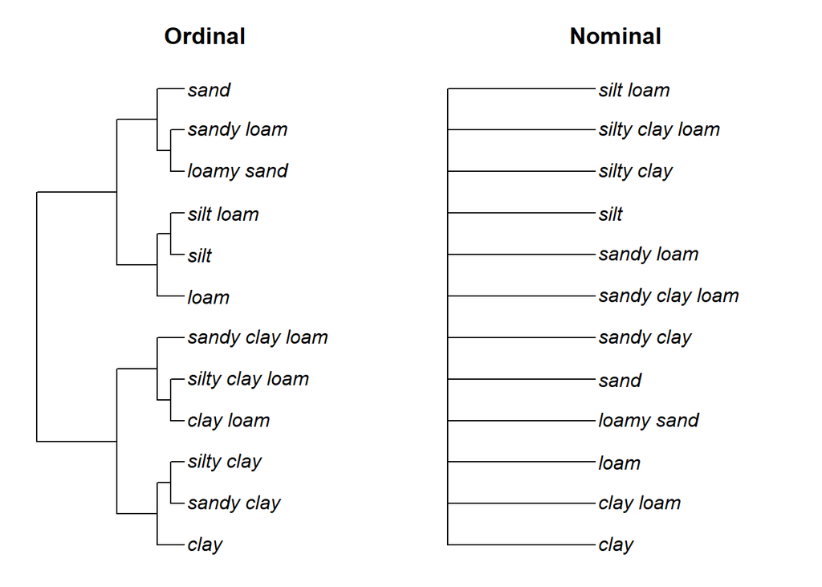

```r
# soil textures, sorted according to field book
data("ROSETTA.centroids")

# ordered vs. nominal texture classes
tex.ordered <- ROSETTA.centroids$texture
tex.nominal <- factor(ROSETTA.centroids$texture, levels=sort(as.character(ROSETTA.centroids$texture)), ordered = FALSE)

# assemble into DF, note that stringsAsFactors=FALSE required
x.1 <- data.frame(
  p1=tex.ordered,
  stringsAsFactors = FALSE
  )

x.2 <- data.frame(
  p1=tex.nominal,
  stringsAsFactors = FALSE
)

# copy texture classes to row names for automatic distance matrix / clustering labels
row.names(x.1) <- x.1$p1
row.names(x.2) <- x.2$p1

# 1D clustering
d.1 <- daisy(x.1[, 1, drop=FALSE], metric = 'gower')
d.2 <- daisy(x.2[, 1, drop=FALSE], metric = 'gower')

## note differences
# d.1
# d.2

# check: pair-wise distances should reflect information contained in ranks of ordinal representation
par(mar=c(1,1,3,1), mfcol=c(1,2))
plot(as.phylo(as.hclust(diana(d.1))), main='Ordinal', label.offset=0.01)
plot(as.phylo(as.hclust(diana(d.2))), main='Nominal', label.offset=0.01)
```

Another reason to use ordered factors when possible: [cophenetic correlation](https://en.wikipedia.org/wiki/Cophenetic_correlation).

```r
# ordinal
cor(d.1, cophenetic(as.hclust(diana(d.1))))
```

```
## [1] 0.7105597
```

```r
# nominal
cor(d.2, cophenetic(as.hclust(diana(d.2))))
```

```
## [1] NA
```

# Sample Data

While the methods outlined in this document can be applied to any collection of pedons, it is convenient to work with a standardized set of data. You can follow along with the analysis by copying code from the following blocks and running it in your **R** session. The sample data used in this document is based on soil profiles that have been correlated to the [Loafercreek](https://soilseries.sc.egov.usda.gov/OSD_Docs/L/LOAFERCREEK.html) soil series from the Sierra Nevada Foothill Region of California. Note that the internal structure of the `loafercreek` data is identical to the structure returned by [`fetchNASIS()` from the soilDB package](http://ncss-tech.github.io/AQP/soilDB/soilDB-Intro.html). All horizon-level values are pulled from the pedon horizon table of the pedons being analyzed.

```r
# load sample data from the soilDB package
data(loafercreek, package = 'soilDB')

# get a subset of profiles to work with
x <- loafercreek[10:20, ]
```

# Methods

## Check Data

```r
# check existing textures
table(x$texture_class)
```

```
##
##  br   c  cb  cl  gr   l scl sil  sl
##   9   4   1  13   2  32   1   5   2
```

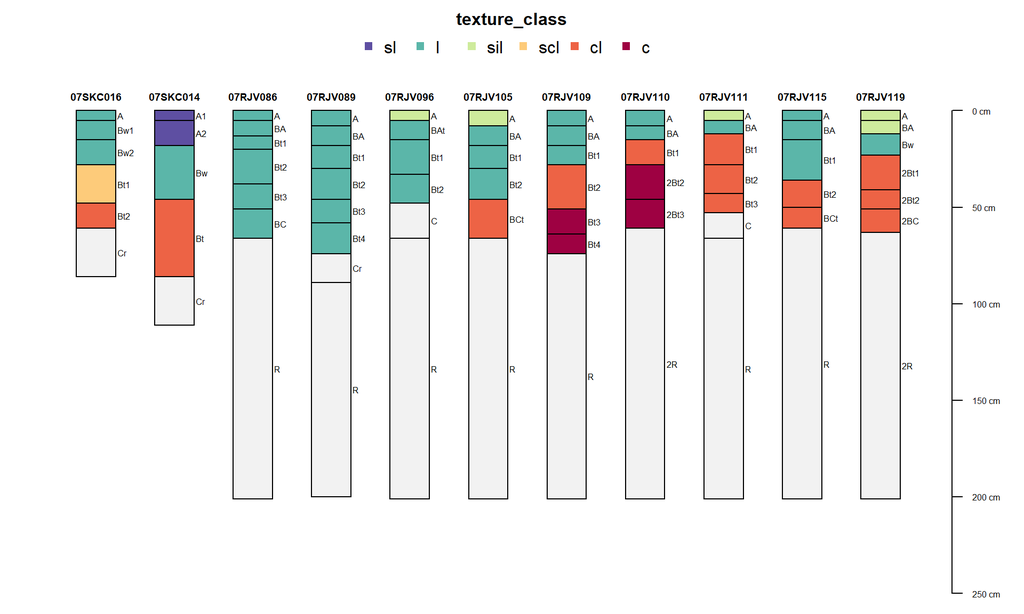

```r
# order field texture according to particle size
# note: leaving out "in-lieu-of" texture classes for organic soil material and bedrock
x$texture_class <- factor(x$texture_class, ordered = TRUE, levels = SoilTextureLevels())
x$texture_class <- droplevels(x$texture_class)

# make a copy same order, but not an ordered factor
x$texture_class_nominal <- factor(x$texture_class, levels=levels(x$texture_class), ordered = FALSE)

# graphical check
par(mar=c(0,1,3,1))
plot(x, color='texture_class', label='pedon_id')
```

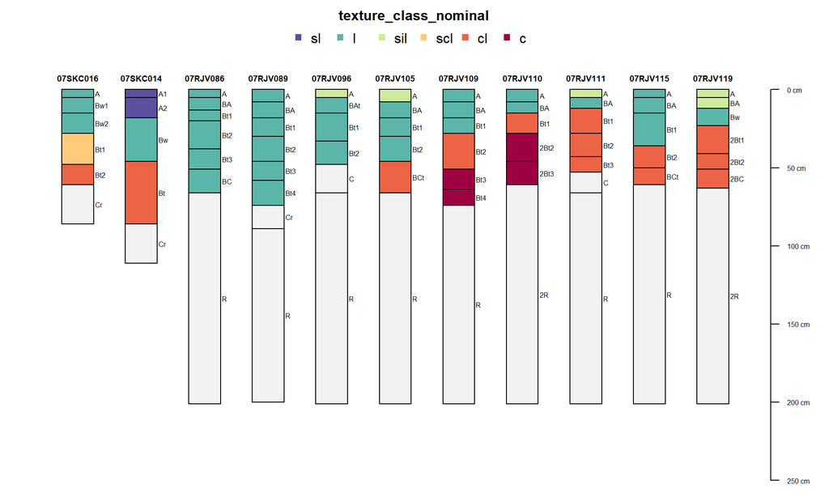

```r
plot(x, color='texture_class_nominal', label='pedon_id')
```

## Horizon Level Attributes

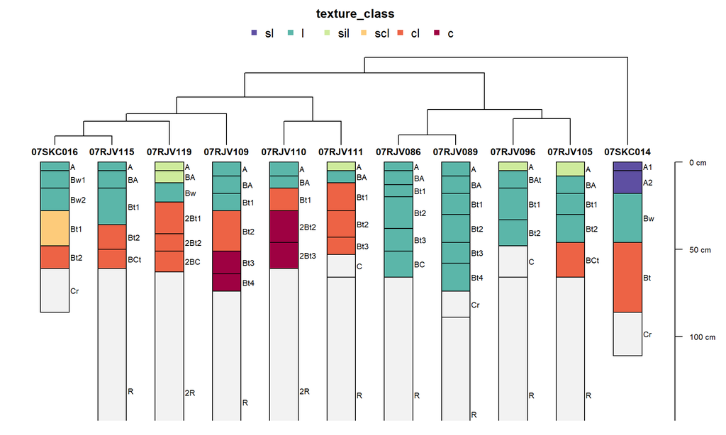

```r
# compute pair-wise distances using texture class (ordered factor)
d.hz <- NCSP(x, vars = c('texture_class'), maxDepth = 100, rescaleResult = TRUE)
# divisive hierarchical clustering
dd.hz <- diana(d.hz)

# plot dendrogram + profiles
par(mar = c(1,0,3,1))
plotProfileDendrogram(x, dd.hz,  width=0.25, color = 'texture_class', label='pedon_id', cex.name=0.65)
```

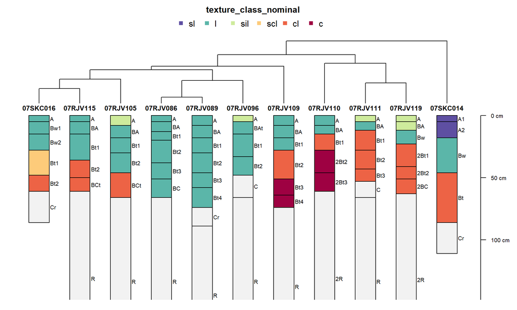

```r
# compute pair-wise distances using texture class (nominal factor)
d.hz <- NCSP(x, vars = c('texture_class_nominal'), maxDepth = 100, rescaleResult = TRUE)
# divisive hierarchical clustering
dd.hz <- diana(d.hz)

# plot dendrogram + profiles
par(mar = c(1,0,3,1))
plotProfileDendrogram(x, dd.hz,  width=0.25, color='texture_class_nominal', label='pedon_id', cex.name=0.65)
```

### Compare Dendrograms

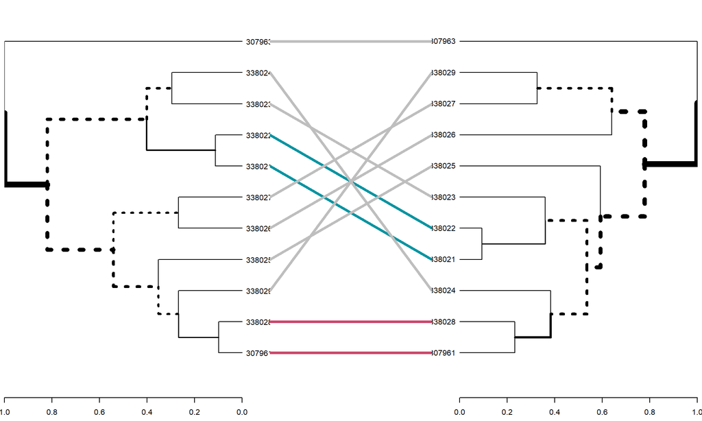

```r
d.ordinal <- NCSP(x, vars=c('texture_class'), maxDepth = 100, rescaleResult = TRUE)
d.nominal <- NCSP(x, vars=c('texture_class_nominal'), maxDepth = 100, rescaleResult = TRUE)

dendextend::tanglegram(as.dendrogram(diana(d.ordinal)), as.dendrogram(diana(d.nominal)))
```

## Site and Horizon Level Attributes

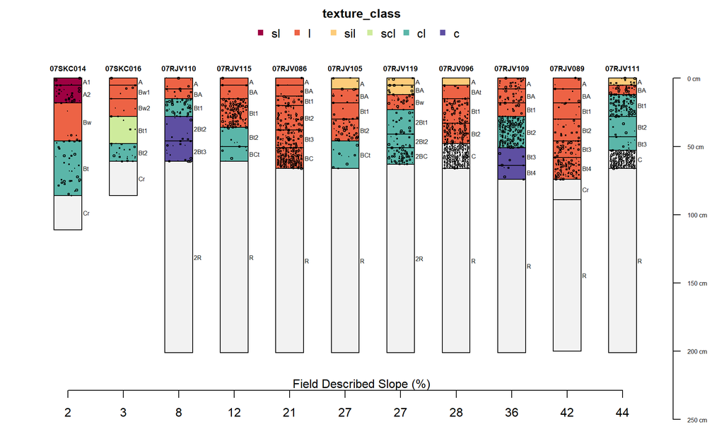

```r
# fix some missing data
x$elev_field[x$elev_field == 0] <- 380

# graphical check: order pedons by slope
par(mar=c(0,1,3,1))
plot(x, color='texture_class', label='pedon_id', col.palette=brewer.pal(10, 'Spectral'), plot.order=order(x$slope_field))
addVolumeFraction(x, 'total_frags_pct')
axis(side=1, at=1:length(x), labels=x$slope_field[order(x$slope_field)], line=-3)
mtext(text='Field Described Slope (%)', side=1, line=-4)
```

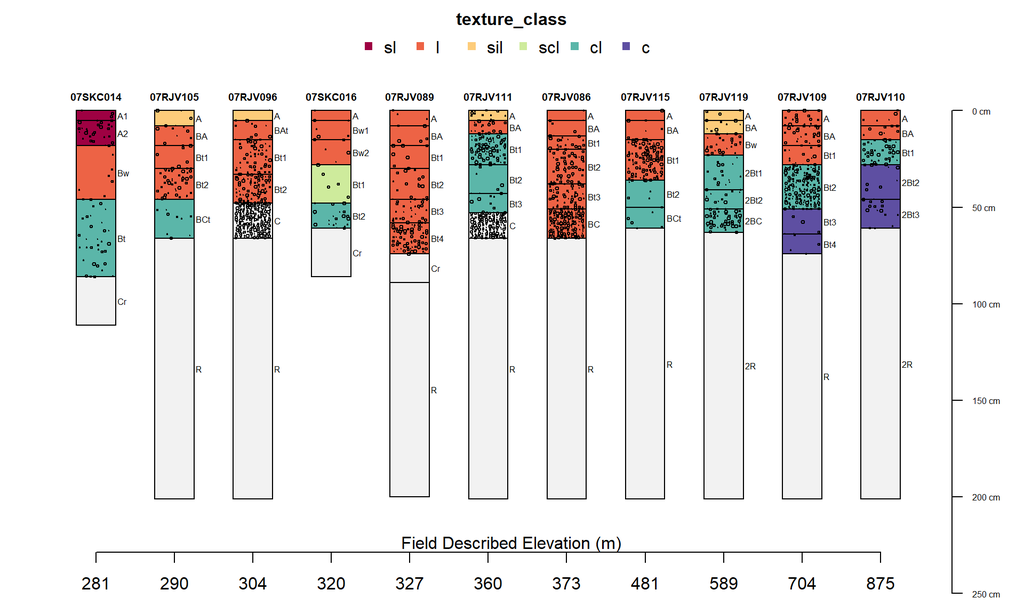

```r
# graphical check: order pedons by elevation
par(mar=c(0,1,3,1))
plot(x, color='texture_class', label='pedon_id', col.palette=brewer.pal(10, 'Spectral'), plot.order=order(x$elev_field))
addVolumeFraction(x, 'total_frags_pct')
axis(side=1, at=1:length(x), labels=x$elev_field[order(x$elev_field)], line=-3)
mtext(text='Field Described Elevation (m)', side=1, line=-4)
```

$D = (D_{s} * w_{s}) + (D_{h} * w_{h}) / (w_{s} + w_{h})$

$\sum_{elements} D{i} * w_{i} / \sum w_{i}$

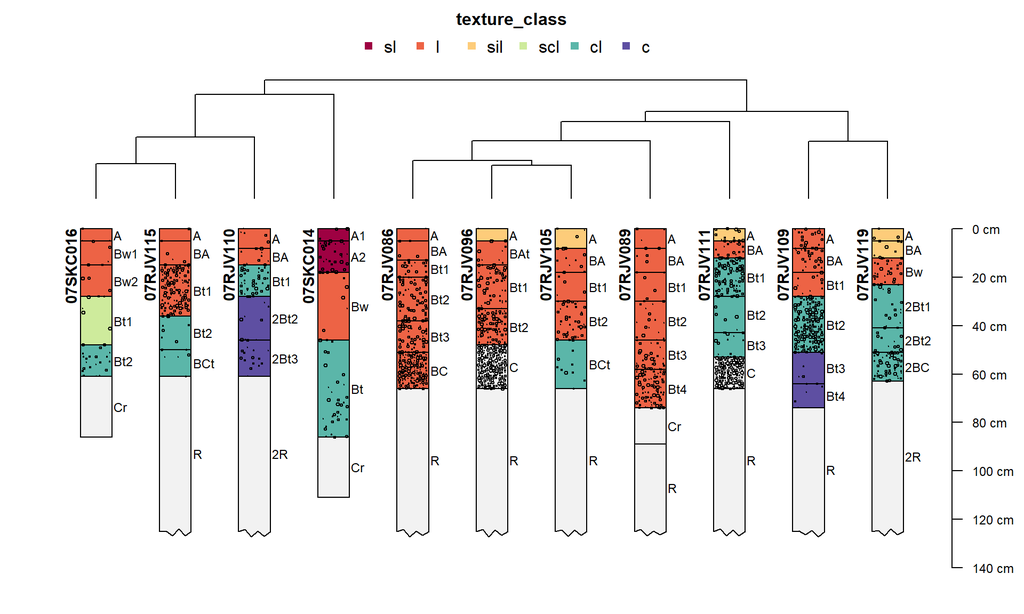

```r
# hz attributes: texture class (ordered factor) and rock frag volume

D.hz <- NCSP(x, vars = c('texture_class', 'total_frags_pct'), maxDepth = 100, rescaleResult = TRUE)
w.hz <- 1

# site attributes: surface slope and elevation
D.s <- compareSites(x, vars = c('slope_field', 'elev_field'))
w.s <- 1

# combine
# note special syntaxt to add distance mat. by element
D <- Reduce(`+`, list(D.s * w.s, D.hz * w.hz)) / sum(c(w.s, w.hz))

# divisive hierarchical clustering
dd.hz.site <- diana(D)

# plot dendrogram + profiles
par(mar = c(2,1,3,1))
plotProfileDendrogram(x, dd.hz.site, scaling.factor = 0.008, y.offset = 0.1, width = 0.2, color='texture_class', label='pedon_id', cex.name=0.75, col.palette=brewer.pal(10, 'Spectral'), max.depth = 125)

addVolumeFraction(x, 'total_frags_pct')
```

This document is based on `aqp` version 2.0, `soilDB` version 2.7.8, and `sharpshootR` version 2.2.